# Analysis of Kriging modeling of zinc in Meuse river

-D.G.P. Madhushanka (MSC-DSA-098)

# 1 Methodology

In this study, we focused on understanding how zinc concentrations are distributed along the Meuse river using advanced spatial analysis techniques, particularly kriging methods. We began by thoroughly examining the Meuse dataset to understand its structure and content, which provided the foundation for our analysis. Through exploratory data analysis (EDA), we gained valuable insights into the distribution patterns of zinc concentrations, using techniques like calculating summary statistics and creating visualizations such as boxplots and spatial maps.

Once we grasped the nature of the data, we transitioned to spatial data preparation, transforming the dataset into a spatial feature object. This step enabled us to capture the spatial relationships inherent in the data, essential for subsequent analyses, especially kriging.

For the core of our analysis, we employed three primary Spatial interpolation techniques: Inverse Distance Weighting (IDW), Ordinary Kriging (OK), and Regression Kriging. These methods, particularly OK and Regression Kriging, offer sophisticated approaches to spatial interpolation, considering both spatial autocorrelation and a deterministic trend. We fine-tuned these kriging models, fitting variogram models and validating their performance to ensure accurate predictions and validate it using RMSE.

The pinnacle of our study was the prediction and mapping of zinc concentrations across the Meuse river region using kriging and done coss validation with RMSE. Leveraging the power of kriging, we generated detailed maps depicting spatially continuous predictions of zinc levels. These maps not only provided insights into the spatial variability of zinc concentrations but also highlighted potential hotspots and areas of environmental concern along the river.

In conclusion, our study showcases the effectiveness of Spatial interpolation techniques in analyzing and predicting spatial variations in zinc concentrations and model validate with RMSE. By integrating advanced spatial analysis methods like kriging into our study and validate accuracy of our kriging model by finding RMSE, we were able to extract meaningful insights, contributing to a better understanding of environmental dynamics in the Meuse river region.

# 2 Exploring Zinc Concentrations in the Meuse Dataset: A Preliminary EDA Before Interpolation

## 2.1 Load necessary libraries

Before running this markdown, please install the following packages if not installed.

```r
library(gstat)
library(tidyverse)
library(viridis)
library(sf)
library(sp)
library(stars)
library(patchwork)
library(ggplot2)
```

## 2.2 Load Meuse dataset and display its structure and first few row

loads the dataset named “meuse” into the current R session.check the data type. show the column content details.

```r
data(meuse)
str(meuse)
```

```
## 'data.frame':    155 obs. of  14 variables:
##  $ x      : num  181072 181025 181165 181298 181307 ...
##  $ y      : num  333611 333558 333537 333484 333330 ...
##  $ cadmium: num  11.7 8.6 6.5 2.6 2.8 3 3.2 2.8 2.4 1.6 ...
##  $ copper : num  85 81 68 81 48 61 31 29 37 24 ...
##  $ lead   : num  299 277 199 116 117 137 132 150 133 80 ...
##  $ zinc   : num  1022 1141 640 257 269 ...
##  $ elev   : num  7.91 6.98 7.8 7.66 7.48 ...
##  $ dist   : num  0.00136 0.01222 0.10303 0.19009 0.27709 ...
##  $ om     : num  13.6 14 13 8 8.7 7.8 9.2 9.5 10.6 6.3 ...
##  $ ffreq  : Factor w/ 3 levels "1","2","3": 1 1 1 1 1 1 1 1 1 1 ...
##  $ soil   : Factor w/ 3 levels "1","2","3": 1 1 1 2 2 2 2 1 1 2 ...
##  $ lime   : Factor w/ 2 levels "0","1": 2 2 2 1 1 1 1 1 1 1 ...
##  $ landuse: Factor w/ 15 levels "Aa","Ab","Ag",..: 4 4 4 11 4 11 4 2 2 15 ...
##  $ dist.m : num  50 30 150 270 380 470 240 120 240 420 ...
```

```r
head(meuse)
```

```
##        x      y cadmium copper lead zinc  elev       dist   om ffreq soil lime
## 1 181072 333611    11.7     85  299 1022 7.909 0.00135803 13.6     1    1    1
## 2 181025 333558     8.6     81  277 1141 6.983 0.01222430 14.0     1    1    1
## 3 181165 333537     6.5     68  199  640 7.800 0.10302900 13.0     1    1    1
## 4 181298 333484     2.6     81  116  257 7.655 0.19009400  8.0     1    2    0
## 5 181307 333330     2.8     48  117  269 7.480 0.27709000  8.7     1    2    0
## 6 181390 333260     3.0     61  137  281 7.791 0.36406700  7.8     1    2    0
##   landuse dist.m
## 1      Ah     50
## 2      Ah     30
## 3      Ah    150
## 4      Ga    270
## 5      Ah    380
## 6      Ga    470
```

### 2.2.1 Summary statistics for zinc

The summary statistics for zinc concentrations in the Meuse dataset indicate a positively skewed distribution with a median of 326 µg/g and a mean of 469.7 µg/g, ranging from 113 µg/g to 1839 µg/g.

```r
summary(meuse$zinc)
```

```
##    Min. 1st Qu.  Median    Mean 3rd Qu.    Max.
##   113.0   198.0   326.0   469.7   674.5  1839.0
```

### 2.2.2 Boxplot of zinc concentrations

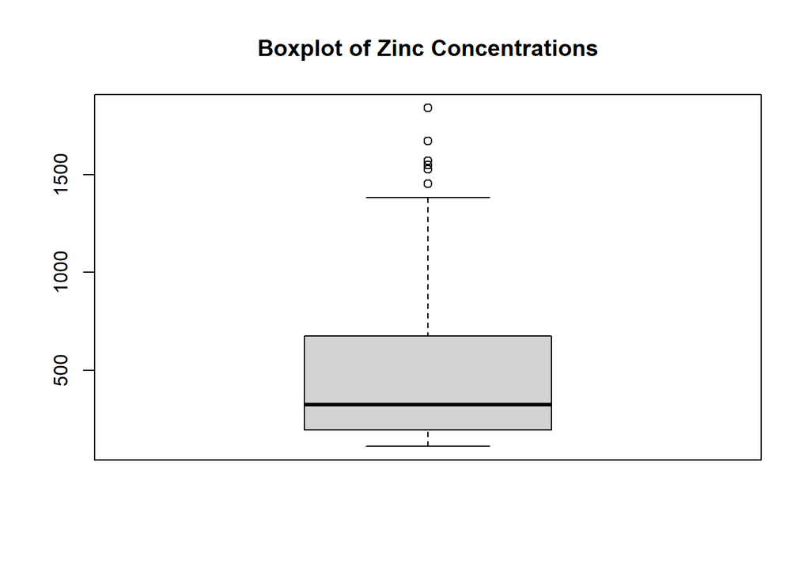

```r
boxplot(meuse$zinc, main = "Boxplot of Zinc Concentrations")
```

Convert the “meuse” dataset to a spatial feature object (sf) with coordinates “x” and “y”.

```r
meuse_sf <- st_as_sf(meuse, coords = c("x", "y"))
```

## 2.3 Zinc Concentration Spatial Distribution in Meuse

### 2.3.1 map zinc spatiol distribution

Geographical trends in zinc concentration distribution within the Meuse dataset reveal higher levels near the riverbank, gradually decreasing towards inland areas It has clear indication on relation ship with the distance to the river from river bank.

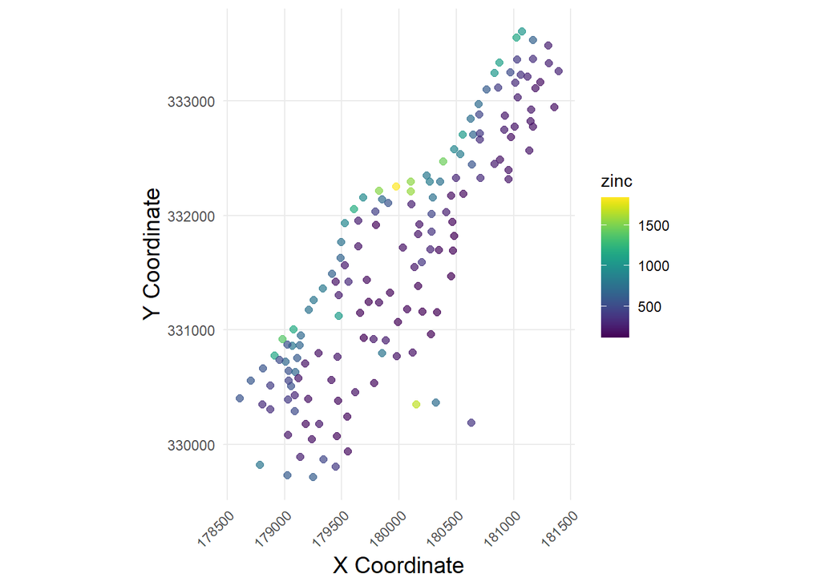

```r
ggplot() +
  geom_sf(data = meuse_sf, aes(color = zinc), size = 2, alpha = 0.7) +
  scale_color_viridis() +
  theme_minimal() + # reduce unnecessary clutter
  theme(axis.text.x = element_text(angle = 45, hjust = 1),  # Rotate x-axis labels
        axis.title = element_text(size = 14))  +  # Adjust axis title size
  labs(x = "X Coordinate", y = "Y Coordinate")  # Add axis labels
```

### 2.3.2 Exploring Zinc Concentration with Distance relationship

Load the “meuse.grid” dataset containing gridded environmental variables for spatial analysis and modeling.

```r
data(meuse.grid)
coordinates(meuse) <- c("x", "y")
coordinates(meuse.grid) <- c("x", "y")
```

Set the spatial coordinates for “meuse.grid” dataset to columns “x” and “y”. The distribution of zinc concentration with distance suggests a logarithmic trend

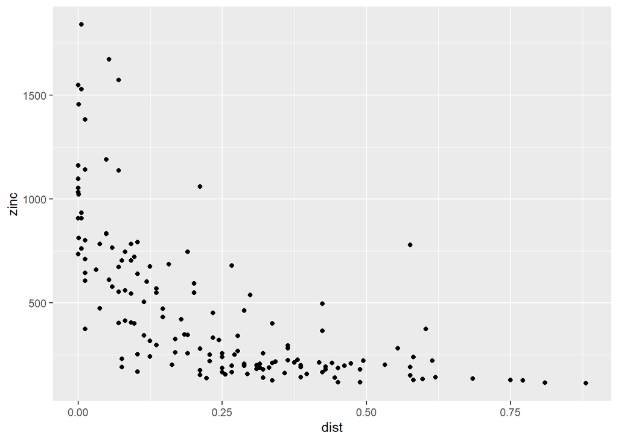

```r
ggplot(meuse_sf,aes(y=zinc,x=dist))+geom_point()
```

further more we are using square root distance with the distancce then we can obain clear relationship as below chart.

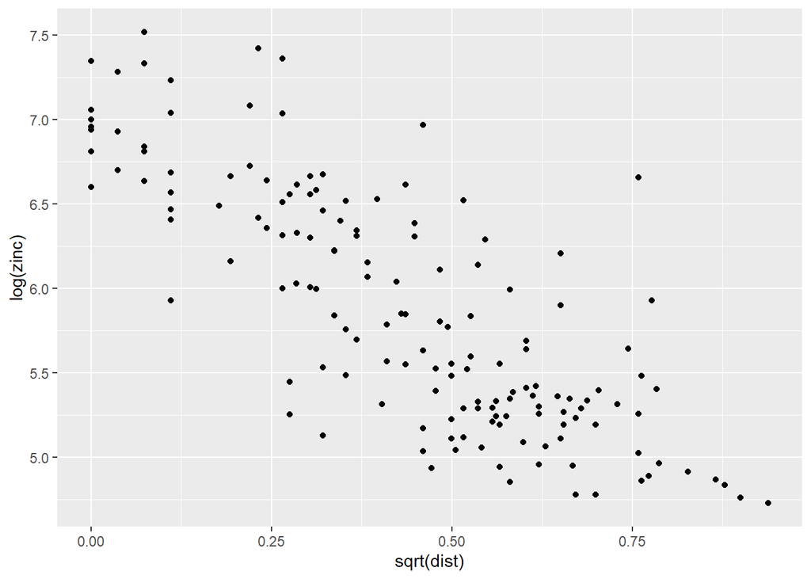

```r
ggplot(meuse_sf,aes(y=log(zinc),x=sqrt(dist)))+geom_point()
```

# 3 Interpolation with Regression krigin

## 3.1 Fitting variogram

we further gig it with variogram analysis on that relationship in spacial pattern

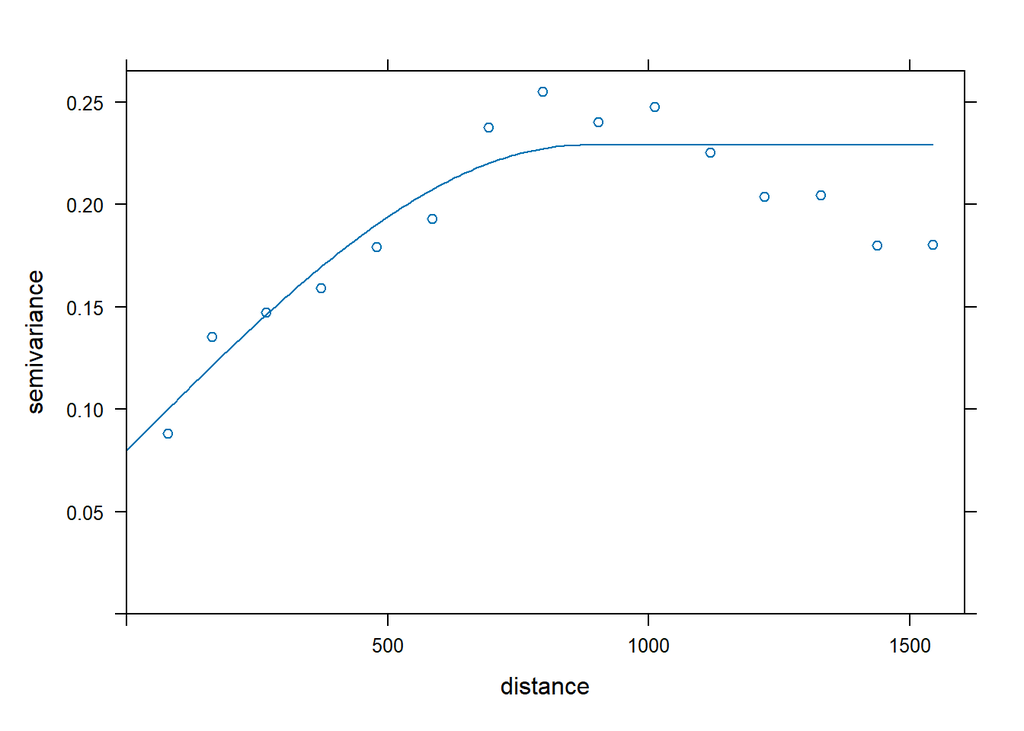

```r
vgmRegression=variogram(log(zinc)~sqrt(dist), meuse)
vgmRegression.fit = fit.variogram(vgmRegression,  model = vgm(1, "Sph", 900, 1))

plot(vgmRegression,vgmRegression.fit )
```

```r
rKrig<- krige(log(zinc) ~ 1, meuse, meuse.grid, model = vgmRegression.fit )
```

```
## [using ordinary kriging]
```

```r
rKrig_df <- data.frame(coordinates(meuse.grid), zinc_predicted = rKrig$var1.pred)
```

## 3.3 Check isotropy

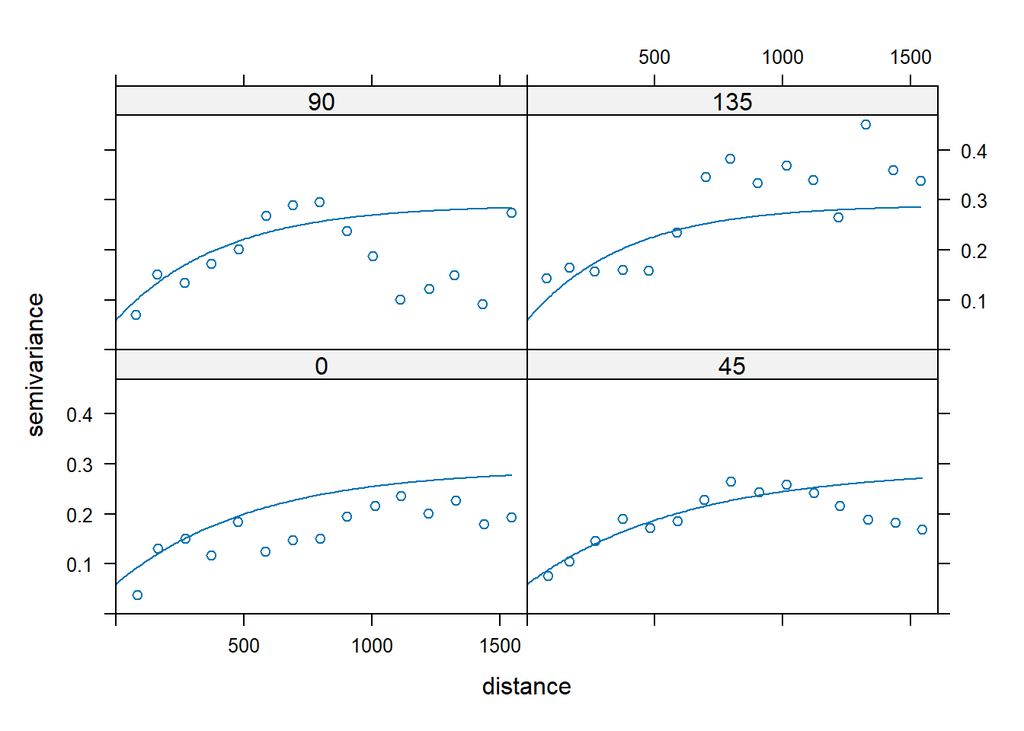

```r
v1.ani <- variogram(log(zinc)~sqrt(dist), alpha = c(0, 45, 90, 135), meuse)
fit.ani <- vgm(psill=.23, model = "Exp", range = 750, nugget = 0.06, anis = c(30, 10, 0, 0.5, 0.3))
plot(v1.ani, fit.ani)
```

## 3.4 Variogram map

With this, we can also say that the mean is distributed slightly equally in all directions.

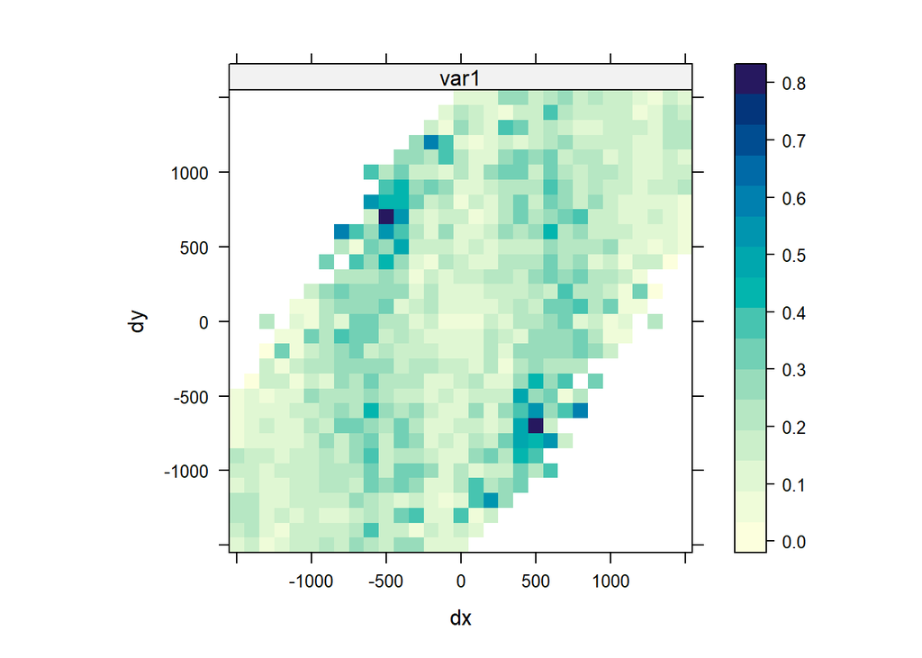

```r
vgm.map <- variogram(log(zinc)~sqrt(dist), meuse, cutoff = 1500, width = 100, map = TRUE)
plot(vgm.map, threshold = 5)
```

we now do the prediction with our above kringng model with interpolated values.

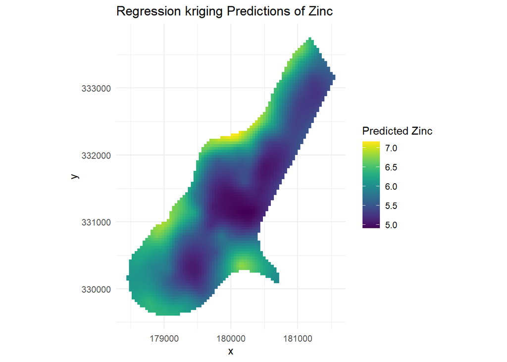

```r
ggplot(rKrig_df, aes(x = x, y = y, fill = zinc_predicted)) +
  geom_tile() +
  scale_fill_viridis() +
  labs(fill = "Predicted Zinc",title = "Regression kriging Predictions of Zinc") +
  theme_minimal() +
  coord_equal()
```

## 3.6 Validation with cross validations.

```r
rKrig.okriging.cv <- krige.cv(log(zinc) ~ 1, meuse, model = vgmRegression.fit)
```

```r
rmseRK <- round(sqrt(mean(rKrig.okriging.cv$residual^2)), 2)
rmseRK
```

```
## [1] 0.42
```

# 4 Interpolation with Ordinary Kriging.

We further fit a kriging with Ordinary krigin for interpolation

## 4.1 Fit variogram with Ordinary kriging

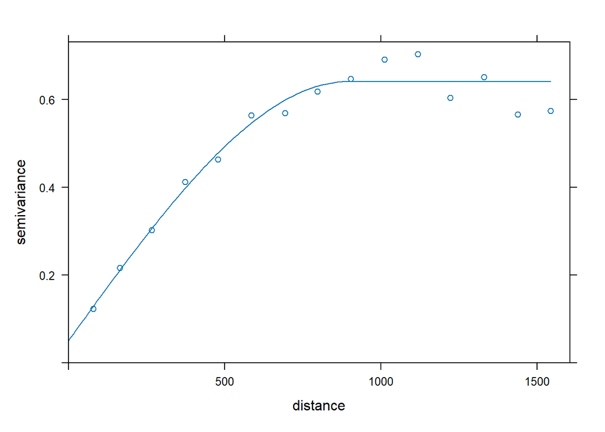

```r
vgm1 = variogram(log(zinc)~1, meuse)

vgm1.fit = fit.variogram(vgm1, model = vgm(psill = 1, model = "Sph", range = 900, nugget = 1))
plot(vgm1, vgm1.fit)
```

## 4.2 Model fit with Ordinary Kriging.

```r
lzn.okriging <- krige(log(zinc) ~ 1, meuse, meuse.grid, model = vgm1.fit)
```

```
## [using ordinary kriging]
```

```r
kriged_df <- data.frame(coordinates(meuse.grid), zinc_predicted = lzn.okriging$var1.pred)
```

## 4.3 Check isotropy in Ordinary kriging

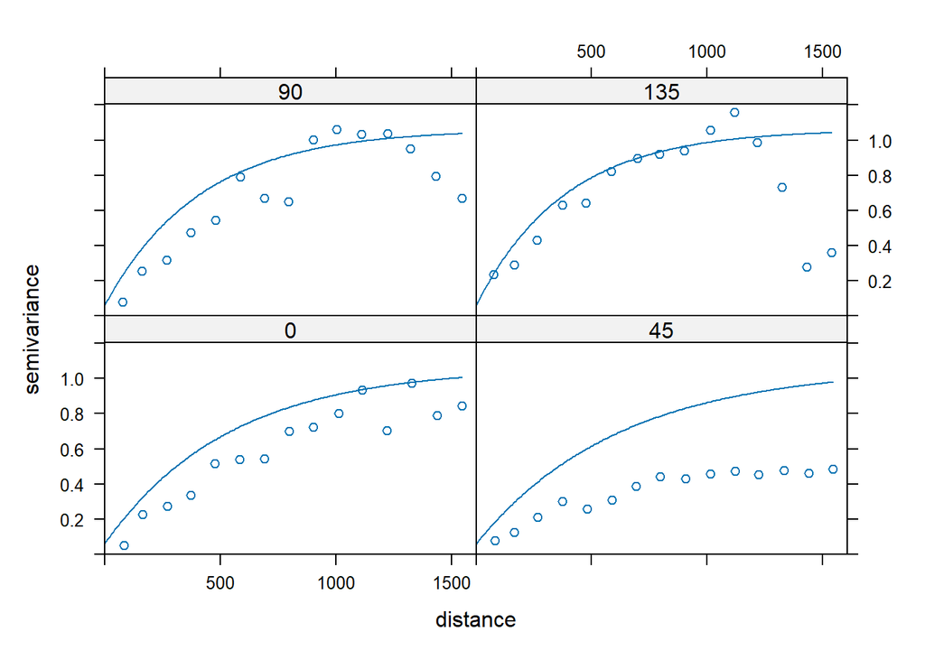

```r
v2.ani <- variogram(log(zinc) ~ 1, alpha = c(0, 45, 90, 135), meuse)
fit2.ani <- vgm(psill=1, model = "Exp", range = 750, nugget = 0.06, anis = c(30, 10, 0, 0.5, 0.3))
plot(v2.ani, fit2.ani)
```

## 4.4 Variogram map

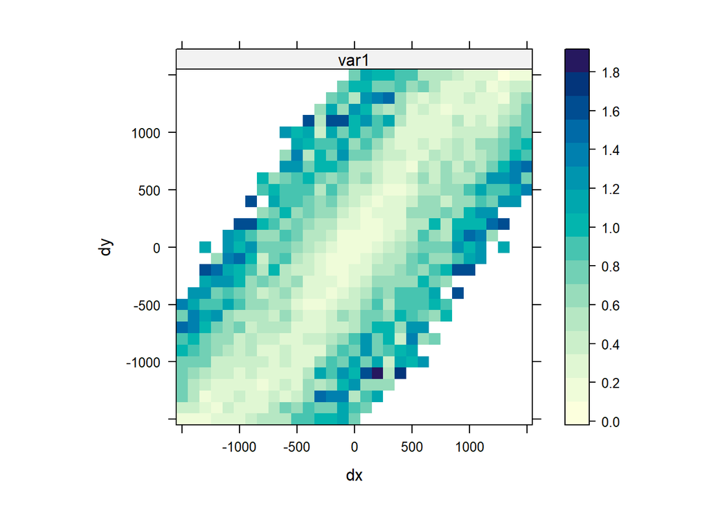

```r
vgm2.map <- variogram(log(zinc) ~ 1, meuse, cutoff = 1500, width = 100, map = TRUE)
plot(vgm2.map, threshold = 5)
```

## 4.5 Plot using Ordinary Kriging map graph

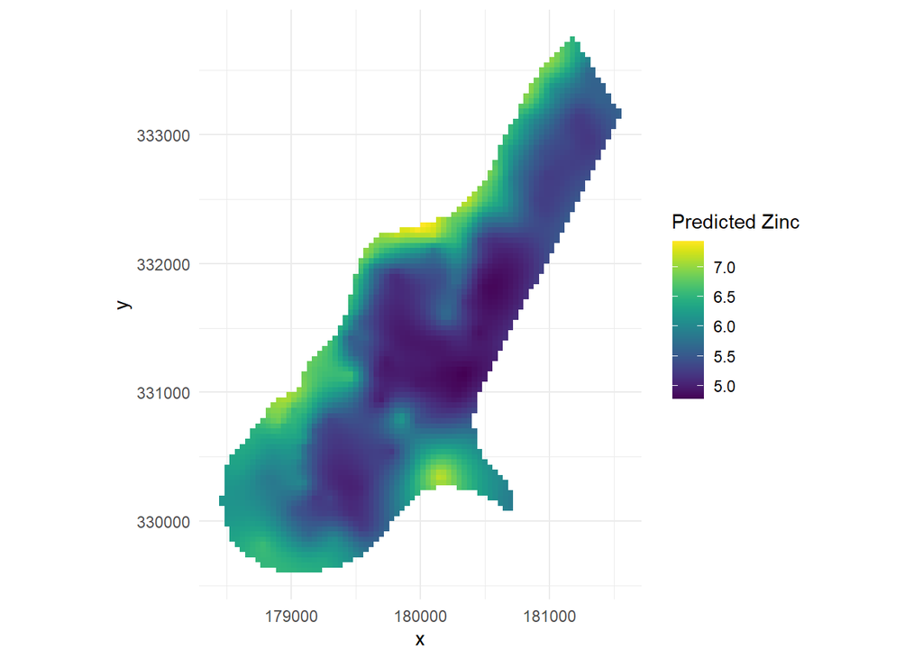

```r
kriged_df <- data.frame(coordinates(meuse.grid), zinc_predicted = lzn.okriging$var1.pred)
ggplot(kriged_df, aes(x = x, y = y, fill = zinc_predicted)) +
  geom_tile() +
  scale_fill_viridis() +
  labs(fill = "Predicted Zinc") +
  theme_minimal()+
  coord_equal()
```

## 4.6 Validation with cross validations Ordinary kriging

```r
lzn.okriging.cv <- krige.cv(log(zinc) ~ 1, meuse, model = vgm1.fit)
```

### 4.6.1 RMSE in Ordinary Kriging.

```r
rmseOK <- round(sqrt(mean(lzn.okriging.cv$residual^2)), 2)
rmseOK
```

```
## [1] 0.39
```

# 5 Interpolation with Inverse Distance Weighting (IDW)

as with above interplication we futher interpolation do with the IDW with Interpoliation spatially continous zinc distribution

## 5.1 IDW on zinc spacial continous distribution

```r
zinc.idw <- idw(zinc ~ 1, meuse, meuse.grid)
```

```
## [inverse distance weighted interpolation]
```

Extract predicted values do the prediction with IDW method.

```r
zinc_idw_pred <- data.frame(coordinates(meuse.grid), zinc = zinc.idw$var1.pred)
```

Convert to data.frame

```r
zinc_idw_df <- as.data.frame(zinc_idw_pred)
```

## 5.2 Plot using IDW map graph

we draw graph with IDW interpolated method.

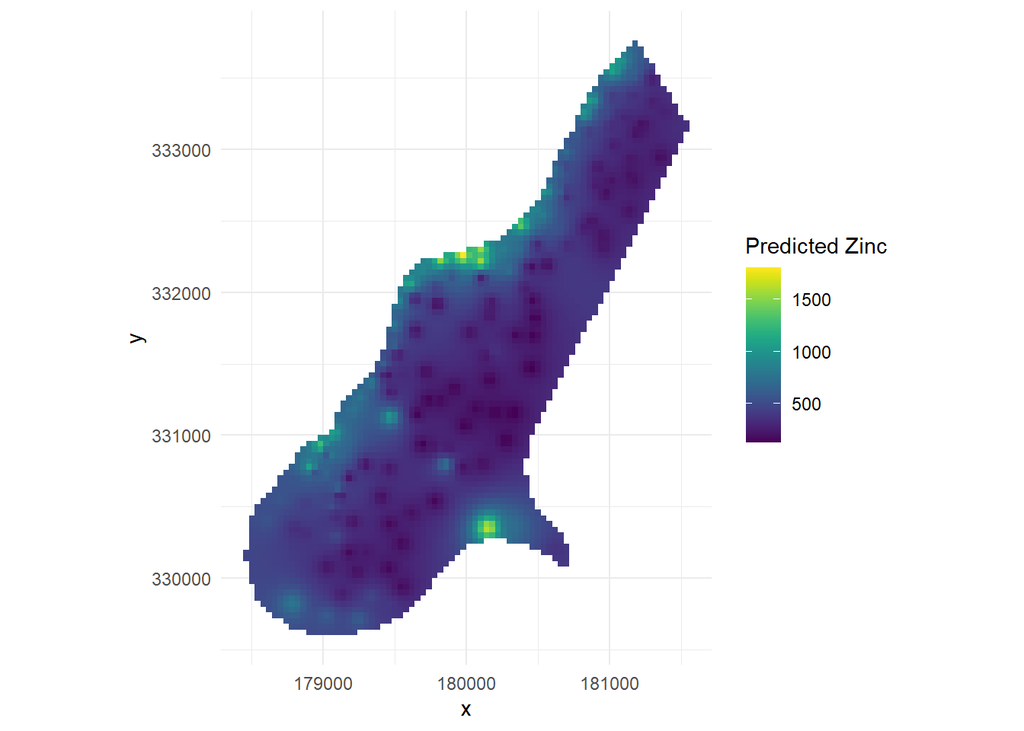

```r
ggplot(zinc_idw_df, aes(x = x, y = y, fill = zinc)) +
  geom_tile() +
  scale_fill_viridis() +
  labs(fill = "Predicted Zinc") +
  theme_minimal() +
  coord_equal()
```

# 6 Concluton

In this analysis of zinc concentrations in the Meuse river region, we employed various spatial interpolation techniques to predict zinc levels across the area. Our exploration began with an examination of the Meuse dataset, revealing spatial patterns in zinc distribution. We then conducted Inverse Distance Weighting (IDW), Ordinary Kriging (OK), and Regression Kriging to interpolate zinc concentrations.

Overall, our analysis demonstrates the utility of kriging techniques in predicting spatially continuous environmental variables like zinc concentrations. By leveraging spatial relationships and variogram modeling, kriging methods offer valuable insights into pollutant distribution patterns, aiding environmental monitoring and management efforts in the Meuse river region and similar areas.

Further more we have validate which kriging method more accurate based on RMSE(Root Mean square error).

[output not shown]

It seems that both Ordinary Kriging and Regression Kriging have nearly equal RMSE values. Therefore, we can assume that both methods are equally good for spatial interpolation zinc concentrations.